# Homework 2

Denis Ostroushko

2022-09-26

```r
# load packages

library(tidyverse)
library(readxl)
library(gridExtra)
library(kableExtra)
```

```r
vc_data <-
  read_xlsx("/Users/denisostroushko/Desktop/UofM MS/MS Fall 2022/Puhb 7405/Data Sets/VitalCapacity.xlsx")
vc_data <- na.omit(vc_data)

colnames(vc_data) <- c("age",  "xvc100")
```

# 4.2

In this section we need to establish the relationship between Age and Vital Lung Capacity for men working in the cadmium industry, but not exposed to the cadmium fumes. We assign X variable to be Age, and Y variable to be Lung Capacity.

### 4.2 - A

To establish connection between age and lung capacity we need to develop a regression model with estimates of $\beta_0$ and $\beta_1$. First, let’s look at the distribution of X and Y.

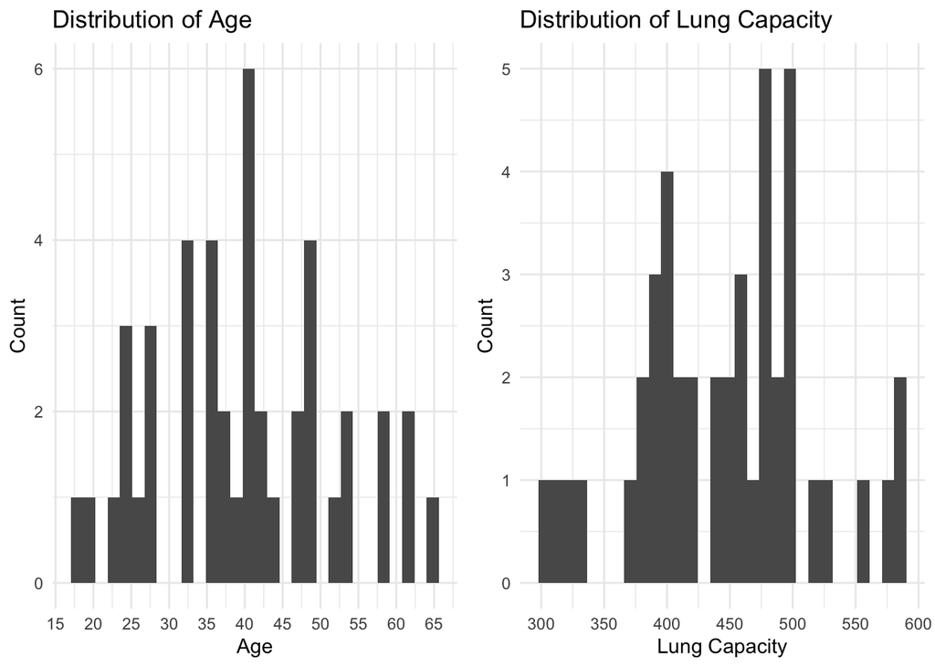

```r
age_plot <-
  ggplot(
    data = vc_data,
    aes(x = age)
  ) + geom_histogram() +

  scale_x_continuous(
    breaks = seq(
      from = round(log10(min(vc_data$age))) * 10^round(log10(min(vc_data$age))),
      to = round(log10(max(vc_data$age))) * 10^round(log10(max(vc_data$age))),
      by = 5
    )
  ) +

  theme_minimal() +
  xlab("Age") +
  ylab("Count") +
  ggtitle("Distribution of Age")

xvc_plot <-
  ggplot(
    data = vc_data,
    aes(x = xvc100)
  ) + geom_histogram() +

  scale_x_continuous(
    breaks = seq(
      from = round(log10(min(vc_data$xvc100))) * 10^round(log10(min(vc_data$xvc100))),
      to = round(log10(max(vc_data$xvc100))) * 10^round(log10(max(vc_data$xvc100))),
      by = 50
    )
  ) +

  theme_minimal() +
  xlab("Lung Capacity") +
  ylab("Count") +
  ggtitle("Distribution of Lung Capacity")

grid.arrange(age_plot, xvc_plot, nrow = 1)
```

Both X and Y have a distribution with a central tendency. Most values seem to be centered around the mean and median of distributions. So, we will expect confidence and prediction intervals for be narrower near average age and lung capacity values, and wider towards the end of the distribution.

We also want to consider the scope of the model. Minimum age in this sample is 18 while maximum age is 65. Therefore, trying to predict lung capacity outside this range can result in predictions with high margin of error. Moreover, we do not know the relationship between lung capacity and age outside of this range, so we will avoid extrapolation.

Finally, we will look at the mean, median, and standard deviation for the two variables. These statistics will give us slightly more insight into the confidence and prediction intervals behavior.

```r
sum_table <-
  data.frame(
    names = c("Age", "Lung Capacity"),
    N = c(length(!is.na(vc_data$age)), length(!is.na(vc_data$xvc100))),
    mean = c(mean(vc_data$age, na.rm = T), mean(vc_data$xvc100, na.rm = T)),
    median = c(median(vc_data$age, na.rm = T), median(vc_data$xvc100, na.rm = T)),
    sd = c(sd(vc_data$age,na.rm = T), sd(vc_data$xvc100, na.rm = T))
  )

colnames(sum_table) <- c("Variable", "N for Analysis", "Mean", "Median", "Standard Deviation")

sum_table %>%
  kbl(align = c(rep('c', length(sum_table)))) %>%
  kable_styling(bootstrap_options = "striped", full_width = F, position = 'center' )
```

| Variable | N for Analysis | Mean | Median | Standard Deviation |
| --- | --- | --- | --- | --- |
| Age | 44 | 39.84091 | 41 | 11.95134 |
| Lung Capacity | 44 | 446.20455 | 453 | 69.22615 |

We do not have missing values, standard deviation is reasonable for both variables in relation to the average values. Mean and median are also pretty close to each other for both variables.

Finally, we can estimate $\beta_0$ and $\beta_1$, we call estimates $b_0$ and $b_1$ respectively.

First need $b_1$, because the value of $b_0$ depends of $b_1$, and we will use this formula Formula:

$$\Large b_1 = \frac{\Sigma (X_i - \bar
X)(Y_i - \bar Y)}{\Sigma (X_i - \bar X)^2}$$

We obtain values from the data set and calculate the value of $b_1$ below:

```r
b1 <-
  sum(
    (vc_data$age - mean(vc_data$age)) * #(x_i - x_bar)
        (vc_data$xvc100 -mean(vc_data$xvc100)) #(y_i - y_bar)
    ) /
  sum((vc_data$age - mean(vc_data$age))^2) # squared error of X
```

Estimate for $\beta_1$ = $\hat \beta_1$ = $b_1$ = -3.0716244

Now we can obtain $b_0$

Formula:

$$\Large \frac{1}{n} (\Sigma Y_i - b_1
\times \Sigma X_i) = \bar Y - b_1 \times \bar X$$

Estimation code is given below

```r
b0 <-
  mean(vc_data$xvc100) - b1 * mean(vc_data$age)
```

Estimate for $\beta_0$ = $\hat \beta_0$ = $b_0$ = 568.580855

To be sure that our calcualtion went right, we can create a linear model in R, and extract estimates from it. Model output is given below:

```r
lm_4_2_a <- lm(xvc100 ~ age, data = vc_data)

sum <- summary(lm_4_2_a)

sum
```

```
##
## Call:
## lm(formula = xvc100 ~ age, data = vc_data)
##
## Residuals:
##     Min      1Q  Median      3Q     Max
## -124.79  -42.75   -1.25   45.20  114.08
##
## Coefficients:
##             Estimate Std. Error t value Pr(>|t|)
## (Intercept) 568.5809    31.4892  18.056  < 2e-16 ***
## age          -3.0716     0.7578  -4.054 0.000214 ***
## ---
## Signif. codes:  0 '***' 0.001 '**' 0.01 '*' 0.05 '.' 0.1 ' ' 1
##
## Residual standard error: 59.39 on 42 degrees of freedom
## Multiple R-squared:  0.2812, Adjusted R-squared:  0.2641
## F-statistic: 16.43 on 1 and 42 DF,  p-value: 0.0002135
```

```r
b0_model <- sum$coefficients[1]
b1_model <- sum$coefficients[2]
```

From the summary of the model we can see that $b_0$ = 568.580855 and $b_1$ = -3.0716244

Difference in two estimates for $b_1$ is 0, rounded to 4 decimal points. Difference in two estimates for $b_0$ is 0, rounded to 4 decimal points.

We have successfully calculated the two estimates we need.

### 4.2 - B

In order to plot regression line we save predicted values from the model to the data frame.

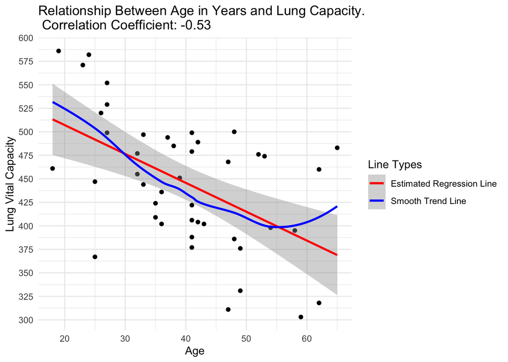

```r
#save estimated data - Y_hat from the mdoel - to the data set for convinient plotting

vc_data$y_hat <- predict(lm_4_2_a, vc_data)

min_round_bound <- round(log10(min(vc_data$xvc100))) * 10^round(log10(min(vc_data$xvc100)))
max_round_bound <- round(log10(max(vc_data$xvc100))) * 10^round(log10(max(vc_data$xvc100)))

ggplot(
  data = vc_data,
  aes(x = age, y = xvc100)
) +
  geom_point() +
  geom_smooth(aes(colour = "Estimated Regression Line"), method = "lm", size = 1, se = T) +
  geom_smooth(aes(colour = "Smooth Trend Line"), se = F) +

  scale_color_manual(name = "Line Types", values = c("Estimated Regression Line" = "red", "Smooth Trend Line" = "blue")) +

  scale_y_continuous(breaks = seq(from = min_round_bound, to = max_round_bound, by = 25)) +
  ylab("Lung Vital Capacity") +
  xlab("Age") +
  ggtitle(paste0("Relationship Between Age in Years and Lung Capacity. \n Correlation Coefficient: ", round(with(vc_data, cor(xvc100, age)),3))) +
  theme_minimal()
```

Overall, regression line follows smooth trend line, so the relationship between the two variables must be linear. At higher age levels the smooth trend line starts to curve, however, there are less data available in that region, so we should be careful with the interpretation of what we see.

We also can see that the variance around fitted regression line is quite large. This is also supported by a wide regression bound around regression line.

### 4.2 - C

Estimated value is 461.0740001

We can also obtain a confidence interval for the mean response level when $X_h = 35$

First, we want a standard error, so we need MSE (Mean Squared Error, obtain from residuals), deviation of $X_h$ from the mean, $\bar X$, and total variance of $X$

We will also obtain a coefficient from the t distribution, at 95% confidence level and 42 degrees of freedom

This is a new formula in this assignment, so we will state it below, before estimating standard error using data.

$$se(b_1)^2 = MSE \times [\frac{1}{n} +
\frac{(X_h - \bar X)^2}{\Sigma (X_i - \bar X)^2}]$$

```r
## se^2 formula: mse (1/n + (x-x_var)^2 / ssx)

X_h <- 35 # desired X level for prediction

df <- nrow(vc_data - 2) # degrees of freedom for studentized T distribution

mse <- sum((vc_data$xvc100 - vc_data$y_hat)^2)/df # mean squared error term from Y -> residals -> ovserved minus predicted
ssx <- sum((vc_data$age - mean(vc_data$age))^2) # sum of squared X deviations

se_sq <- mse * (1/nrow(vc_data) + (X_h - mean(vc_data$age))^2 / ssx ) #standard error squared

t_coef <-
  abs(
    qt(
      1-.05/2,
      nrow(vc_data) - 2
      )
  ) # coefficient T

est <- b0 + b1*X_h # point estimate of E[Y_h]

ci_low <- est - sqrt(se_sq) * t_coef # lower bound of confidence interval
ci_high <- est + sqrt(se_sq) * t_coef # upper bound of confidence interval
```

We estimate that the average lung capacity for men who are 35 years old will be 461.0740001, with a confidence interval given by ( 441.9978249, 480.1501753).

Again, we can check our work using existing R functions. We will estimate average lung capacity of 35 year old males using code below. It also conveniently provides a confidence interval.

```r
# predict mean response using R function

predict(lm_4_2_a, data.frame(age = X_h), interval = "confidence")
```

```
##       fit      lwr      upr
## 1 461.074 441.5489 480.5991
```

The two sets of estiamtes align very closely.

### 4.2 - D

Mean response is the average change in response variable ,lung capacity function, when X , age, is increased by 1 unit, i.e. when person gets one year odler. When age increases by 1 year then VC changes by -3.0716244 units. However, it makes more sense to say that one additional year of age decreases the lung capacity by an overage of 3.0716244 units.

Since the relationship is linear, when a person gets 10 years older, VC decreases by 30.7162443

# 5.3

```r
cig <- read_xls("/Users/denisostroushko/Desktop/UofM MS/MS Fall 2022/Puhb 7405/Data Sets/Cigarettes.xls")

original_names <- colnames(cig)

colnames(cig) <- c("age", "gender", "cpd", "carbon_mono", "cotinine", "nnal")
```

Before we can get an estimate and interpret the meaning of the confidence interval we need to take a look at the summary statistics and the distribution of two variables.

```r
sum_tab <-
  with(cig,
  data.frame(
    names = c("CPD", "Cotinine"),
    N = c(
      length(!is.na(cpd)),
      length(!is.na(cotinine))
    ),
    Mean = c(
      mean(cpd, na.rm = T),
      mean(cotinine, na.rm = T)
    ),
    Median = c(
      median(cpd, na.rm = T),
      median(cotinine, na.rm = T)
    ),
    sd = c(
      sd(cpd, na.rm = T),
      sd(cotinine, na.rm = T)
    )
  )
)

colnames(sum_tab) <- c("Variable", "N", "Mean", "Median", "Standard Deviation")

sum_tab %>%
  kbl(align = rep(c(rep('c', length(sum_tab))))) %>%
  kable_styling(bootstrap_options = "striped", full_width = F, position = 'center')
```

| Variable | N | Mean | Median | Standard Deviation |
| --- | --- | --- | --- | --- |
| CPD | 86 | 11.000 | 10.0 | 11.93019 |
| Cotinine | 86 | 2365.709 | 1623.5 | 2073.15867 |

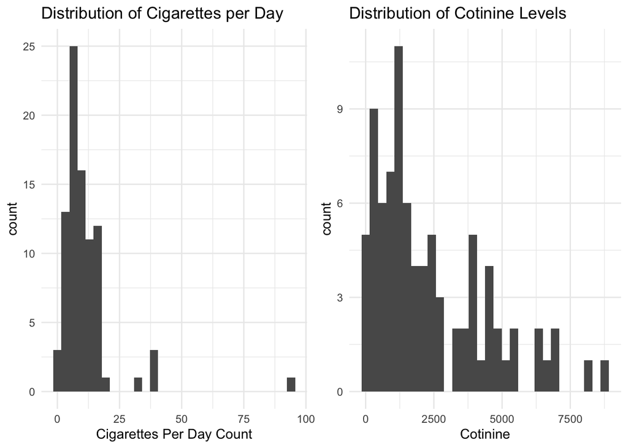

```r
cpd_plot <-
  ggplot(
    data = cig,
    aes(x = cpd)
  ) +
  ggtitle("Distribution of Cigarettes per Day ") +
  xlab("Cigarettes Per Day Count") +
  geom_histogram()  +
  theme_minimal()

cot_plot <-
  ggplot(
    data = cig,
    aes(x = cotinine)
  ) +
  ggtitle("Distribution of Cotinine Levels ") +
  xlab("Cotinine") +
  geom_histogram()  +
  theme_minimal()

grid.arrange(cpd_plot, cot_plot, nrow = 1)
```

These two variables are heavily skewed, with long tails that have heavy outliers. This was expected when we look at the summary statistics. The mean is greater than the median, which usually means that there are a few outliers on the far positive side, which increase the value of the mean. Visual summary confirms this. Additionally, when we see a large value of standard deviation, this is another sign that there are huge positive outliers.

We also will take a look at the relationship between CPD and Cotinine levels using a scatter plot.

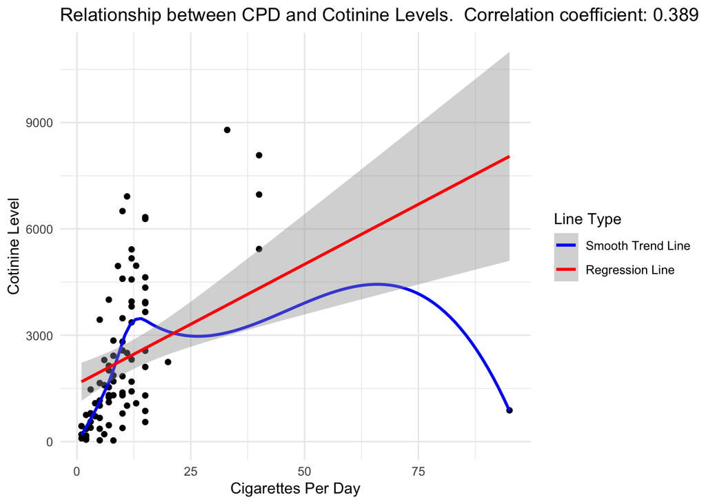

```r
ggplot(data = cig,
       aes(x = cpd, y = cotinine)) + geom_point() +
  stat_smooth(aes(colour = "Smooth Trend Line"), size = 1, se = F) +
  geom_smooth(method = "lm", size = 1, se = T, aes(colour = "Regression Line")) +

  xlab("Cigarettes Per Day") +
  ylab("Cotinine Level") +
  ggtitle(paste0("Relationship between CPD and Cotinine Levels. \ Correlation coefficient: ", round(with(cig, cor(cpd, cotinine)), 3))) +

  theme_minimal() +

  scale_color_manual(
    name = "Line Type", values = c("Smooth Trend Line" = "blue", "Regression Line" = "red")
  )
```

Overall,we should expect a very poor fit of regression model to this data. There are several outliers that skew the fitted line. Especially a data point for someone who smokes over 75 cigarettes per day, but has cotinine levels that are more common for people who smoke between zero and ten cigarettes per day. However, we are not tasked with diagnostics and data tuning in this assignment, so we leave the data point here.

### 5.3 - A

We need to estimate average response when $X_h = 30$, 30 cigarettes per day, and obtain a confidence interval for it.

We showed how to estimate model parameters, average response level and confidence interval by hand in 4.2, so we will use R functions to get estimates for interpretations.

We provide a summary of the model that we use to obtain an estimate.

```r
lm_5_3 <- lm(cotinine ~ cpd, data = cig)
summary(lm_5_3)
```

```
##
## Call:
## lm(formula = cotinine ~ cpd, data = cig)
##
## Residuals:
##     Min      1Q  Median      3Q     Max
## -7166.0 -1284.0  -545.2  1247.0  4938.1
##
## Coefficients:
##             Estimate Std. Error t value Pr(>|t|)
## (Intercept)  1621.60     282.52   5.740 1.47e-07 ***
## cpd            67.65      17.46   3.873 0.000212 ***
## ---
## Signif. codes:  0 '***' 0.001 '**' 0.01 '*' 0.05 '.' 0.1 ' ' 1
##
## Residual standard error: 1921 on 84 degrees of freedom
## Multiple R-squared:  0.1515, Adjusted R-squared:  0.1414
## F-statistic:    15 on 1 and 84 DF,  p-value: 0.0002119
```

```r
predict(lm_5_3, data.frame(cpd = 30), interval = "confidence")
```

```
##        fit      lwr     upr
## 1 3650.992 2873.095 4428.89
```

We estimate that people who smoke 30 cigarettes per day have cotinite level of 3650.9922417, bounded by (2873.0946136, 4428.8898697).

There confidence interval is very wide, because we estimate the response level for values that are quite far from the average value of cigarettes per day, which is 11. This high distance from the center of the distribution contributes to the standard error a lot. Moreover, we do not have enough data in that region of the distribution of CPD, and we can even make an argument that 30 cigarettes per day may be considered outside of the model scope, if we change the way these data were collected.

### 5.3 - B

Obtaining a prediction interval for a single new observed value is a new exercise in this homework, so we will state the formula below. We will also use a built in function to validate our results.

$$se(Y_{h (new)})^2 = MSE * [1 +
\frac{1}{n} + \frac{(X_{h (new)} - \bar X)^2}{\Sigma (X_i - \bar
X)^2}]$$

```r
X_h <- 30

n <- nrow(cig)

mse <- sum(lm_5_3$residuals^2)/(n-2)

ssx <- sum( (cig$cpd - mean(cig$cpd))^2 )

se_y_h_new <-
  sqrt(
    mse * (1 + 1/n + (X_h - mean(cig$cpd))^2 / ssx)
  )

t_coef <- qt(1 - .05/2, n - 2)

ci_lower <- (b1 * X_h + b0) - se_y_h_new * t_coef
ci_upper <- (b1 * X_h + b0) + se_y_h_new * t_coef
```

we can check the result using the function below:

```r
predict(lm_5_3, data.frame(cpd = 30), interval = "prediction")
```

```
##        fit       lwr      upr
## 1 3650.992 -247.4502 7549.435
```

Note that the cotinine levels range from 32 and 8792 in the sample of data we have for analysis. This means that the prediction interval spans over almost entire range of the Y variable. We saw in the introduction of this analysis section that the two variables have outliers and extreme values. They contribute meaningfully to the standard error and uncertainty in the estimate. Moreover, estimating a prediction interval for a single observation brings another level of uncertainty and variation. All together these factors result in a prediction interval that is essentially unusable, since it captures alsmost the entire range of cotinine values.

### 5.3 - C

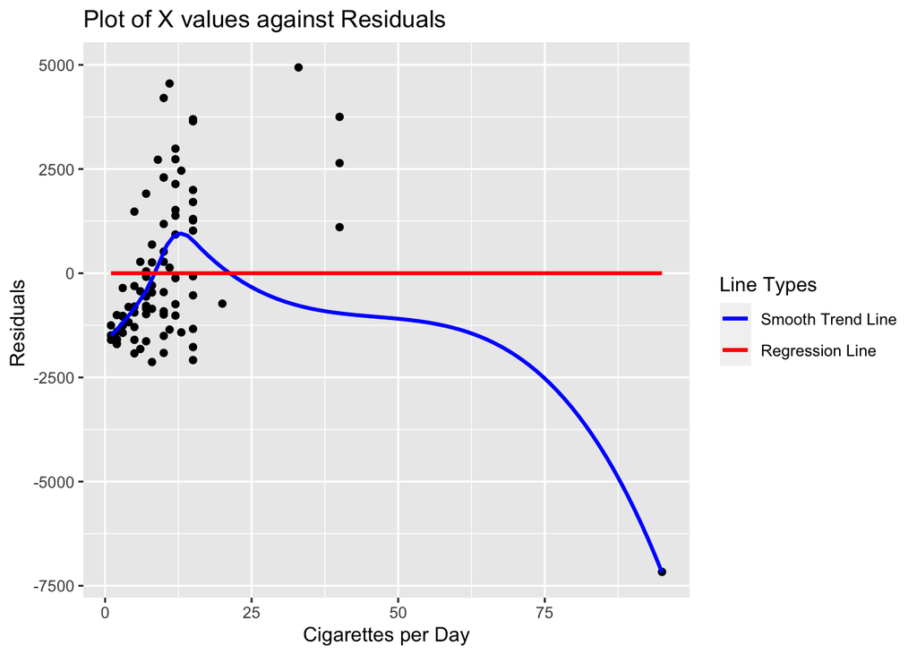

```r
cig$resid <- lm_5_3$residuals

ggplot(data = cig,
       aes(x = cpd, y = resid)) +
  geom_point() +
  geom_smooth(aes(color = "Smooth Trend Line"), se = F, size = 1) +
  stat_smooth(aes(color = "Regression Line") , se = F,  size = 1, method = "lm") +

  xlab("Cigarettes per Day") +
  ylab("Residuals ") +
  ggtitle( "Plot of X values against Residuals "
  ) +

  scale_color_manual(name = "Line Types", values = c("Smooth Trend Line" = "blue", "Regression Line" = "red"))
```

We can also see that residuals may vary between 2500 and 5000 values, which is a large error.

```r
summary(cig$resid)
```

```
##    Min. 1st Qu.  Median    Mean 3rd Qu.    Max.
## -7166.0 -1284.0  -545.2     0.0  1247.0  4938.1
```

average residual value: 0, which also follows a model assumption.

### 5.3 - D

We can set up the ANOVA table using a model we created earlier and a simple function available in R.

First of all we can observe that the sum of squares is huge for both regression and error terms. We saw that residuals had a lot of variation when evaluating the residual plot. We also know that regression mean square would be large because of extreme values and outliers in the data.

ANOVA table allows us to test the following hypotheses:

$H_0: \beta_1 = 0$

$H_a: \beta_1 \neq 0$

```r
anova(lm_5_3)
```

```
## Analysis of Variance Table
##
## Response: cotinine
##           Df    Sum Sq  Mean Sq F value    Pr(>F)
## cpd        1  55360992 55360992  15.003 0.0002119 ***
## Residuals 84 309967894  3690094
## ---
## Signif. codes:  0 '***' 0.001 '**' 0.01 '*' 0.05 '.' 0.1 ' ' 1
```

```r
f <- anova(lm_5_3)$`F value`

f_cutoff <- qf(1-0.05, 1, nrow(cig) - 2)
```

The goal of the ANOVA table is to evaluate the relationship response and predictor when comparing the portion of variation explained by the predictor. If the regression mean square is large, then the coefficient of the fitted line is far from zero, and must be related to the response variable. If the error mean square is small, then the values of response are distributed close to the fitted line, and therefore predictor value is a good proxy for values of Y.

So, we obtain an F statistic to see is regression mean square is far greater than the error mean square.

$$\Large F statistic = F^* =
\frac{Regression MS}{Residual MS }$$

Hence, the cutoff value for $F$ = 3.9545684 for the 95% confidence level.

Clearly, 15.0025968 > 3.9545684, so we reject the null hypothesis and accept that $\beta_1$ is not zero. Therefore, there exists a statistically significant relationship between Cotinine levels and the daily cigarette consumption.